# RSV (ABRYSVO) - Guillain-Barre syndrome

OpenSourcePV

Data Lock Point: 2024_02_23

# 1 Quantitative Signal status

## 1.1 Disproportionality

The vaccine-event combination “RSV (ABRYSVO) - Guillain-Barre syndrome” was **a signal of disproportionate reporting** with an EB05 value of 2.51.

The threshold for being flagged as a signal of disproportionate reporting is an EB05>=2 meaning that there there is a 95% probability that the reporting of Guillain-Barre syndrome was at least twice post exposure to RSV (ABRYSVO) than post all vaccines [1]. Under the assumption of no causality between RSV (ABRYSVO) and Guillain-Barre syndrome and no bias it would have been expected to observe an EBGM of 1.

It means that the quantified causality criterion of strength of association is **met**.

*It is to be noted that the nature of the spontaneous report does not provide reliable estimates of the strength of association (whatever the choice of the disproportionality method) and that some reporting bias or difference in demographic characteristics might explain the (un)observed disproportion*.

## 1.2 Time-to-onset

The vaccine-event combination “RSV (ABRYSVO) - Guillain-Barre syndrome” was **not a signal of unexpected time-to-onset distribution** with a p-value of the two-sample Kolmogorov-Smirnov test being 0.204317 and distance between the two empirical cumulative distributions being of 25.949881%.

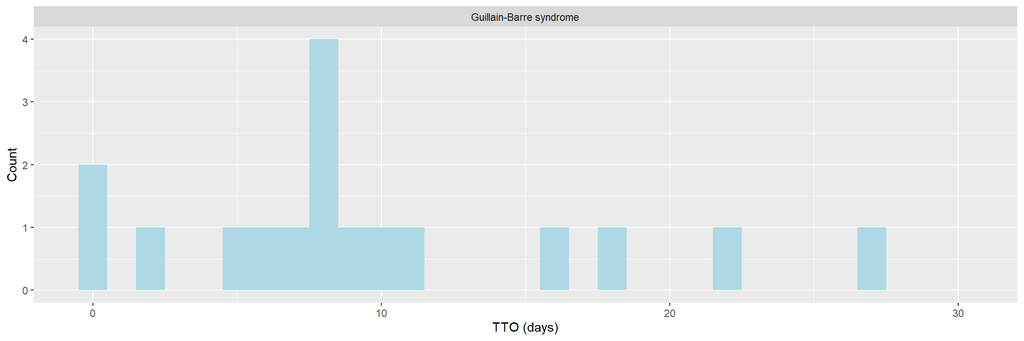

The TTO signal detection method tests if the distribution of Guillain-Barre syndrome post RSV (ABRYSVO) is significantly different from the distribution of Guillain-Barre syndrome post other vaccines using a two-sample Kolmogorov-Smirnov test [2]. The threshold for being flagged as a signal of unexpected time-to-onset distribution is a P-value <0.001 and a distance between the two empirical distributions larger than 20%. Under the assumption of no causality and no bias, it would have been expected that the time-to-onset distribution for “Guillain-Barre syndrome” would have been the same post RSV (ABRYSVO) than post other vaccines.

It means that the quantified causality criterion of temporality is **not met**.

*It is to be noted that the nature of the spontaneous report does not provide reliable estimates of the temporal relationship between the exposure and the occurrence of the events as there is the reporting bias over time: the latter the event occurs after exposure, the less chance it has to be reported. Other biases could distort the reported time-to-onset distribution (media attention, etc.)*

## 1.3 Overall

Based on the screening of the Empirical Bayes Geometric Mean (EBGM) and the screening of the time-to-onset distribution,the vaccine-event combination “RSV (ABRYSVO) - Guillain-Barre syndrome” is **considered as quantitative signal**.

# 2 Signal History

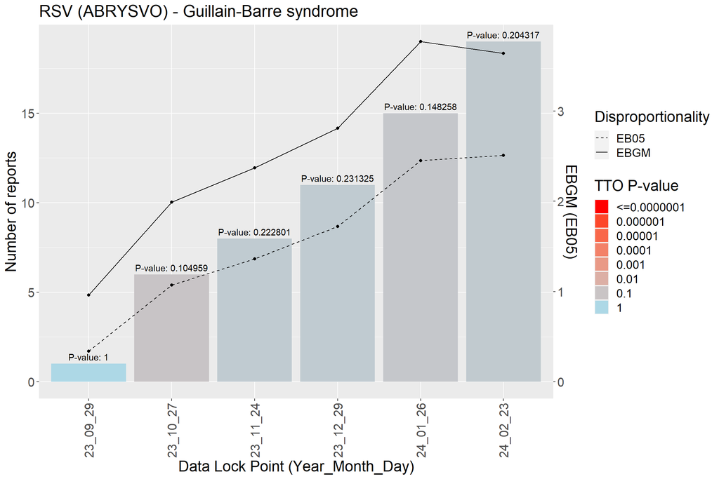

# 3 Case series

## 3.1 Characterization of the case series using vigipoint

Vigipoint [3] provides a way to pinpoint key features within the vaccine-event case series “RSV (ABRYSVO) - Guillain-Barre syndrome” which are imbalanced (either with excess or deficit) compared to what you would expect looking at how these features are globally distributed within “RSV (ABRYSVO)”.

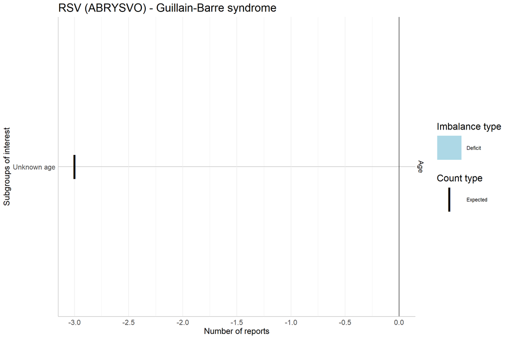

## 3.2 Seriousness

A total of 19 reports of Guillain-Barre syndrome were received post exposure to RSV (ABRYSVO). Among them:

- 0 (0.0 %) were fatal cases.
- 7 (36.8 %) were life threatening cases.
- 17 (89.5 %) were hospitalized cases.
- 0 (0.0 %) were emergency room cases.
- 8 (42.1 %) were cases with disabilies.

4 new cases were received since last data refresh.

## 3.3 Demographic characteristics

19 cases of Guillain-Barre syndrome post RSV (ABRYSVO) were reported in VAERS:

- Among them, there were 8 (42.1%) female cases and 10 (52.6%) male cases while the overall female:male ratio is 62:27%.
- The mean (median) age for patients presenting symptoms of Guillain-Barre syndrome was 69 (72) years while the overall mean (median) age was 68 (71) years.
- The top 5 contributing US states for patients presenting symptoms of Guillain-Barre syndrome were KY ( 10.5 %) , TX ( 10.5 %) , AZ ( 5.3 %) , CA ( 5.3 %) , IA ( 5.3 %) while overall the top 5 of contributing US states are NA ( 12.1 %) , CA ( 6.5 %) , OH ( 5.1 %) , PA ( 5 %) , NY ( 4.9 %)

# 4 Manufacturing

# 5 Listing of the cases

Narratives can be made visible clicking on the ⊕ symbol.

|  | VAERS ID | Sex/Age (Years) | Receipt Date | Seriousness status | List of symptoms | New | SYMPTOM_TEXT |
| --- | --- | --- | --- | --- | --- | --- | --- |
| &oplus; | 2744229 | M/74 | 02/06/2024 | Life threatening &amp; Hospitalized | Areflexia, Asthenia, Atrial fibrillation, Blood glucose increased, Computerised tomogram, Diplopia, Dysstasia, Fatigue, Gait disturbance, Guillain-Barre syndrome, Immunoglobulin therapy, Joint stiffne… | Yes | He got his vaccine he noticed in his ankles and his calves were tightening up and getting harder for him to stand or walk It got to a point that he could not stand long enough to brush his teeth The p… |
| &oplus; | 2744371 | Unknown Sex/NA | 02/06/2024 | Hospitalized | CSF protein increased, Dysarthria, Facial paralysis, Facial paresis, Gait disturbance, Guillain-Barre syndrome, Immunoglobulin therapy, Intensive care, Neuralgia, Pain in extremity | Yes | Severe leg nerve pain fat night right side facial droop w slurred speech instability in walking Diagnosed w Gillian Barre Syndrome Treatment five 5 IVIG infusion in ICU Outcome No more nerve pain Stil… |
| &oplus; | 2745913 | F/28 | 02/12/2024 | Hospitalized | Acidosis, Ageusia, Angiogram, Bell's palsy, Blood electrolytes, Central venous catheterisation, Computerised tomogram, Delivery, Dialysis, Dyskinesia, Exposure during pregnancy, Eyelid function disord… | Yes | 12 19 23 2343 The patient complains of left sided facial weakness She was trying to drink out of a straw and had difficulty She also has some neck and facial pain She does not have any weakness in her… |
| &oplus; | 2748681 | M/72 | 02/22/2024 | Life threatening &amp; Hospitalized | Arthralgia, Guillain-Barre syndrome, Malaise, Paraesthesia | Yes | VACCINATION WAS DONE ON 1 18 2024 PATIENT PRESENTED TO EMERGENCY DEPARTMENT OF LOCAL HOSPITAL ON 1 29 24 COMPLAINING OF SHOULDER PAIN HE WAS DISCHARGED TO HOME SAME DAY HE AGAIN WENT TO EMERGENCY DEPA… |
| &oplus; | 2683554 | M/80 | 09/19/2023 | Hospitalized | Blood pressure increased, Gait inability, Guillain-Barre syndrome, Hypoaesthesia | No | 5 days after administration blood pressure spiked and started having numbness in his fingers the numbness went to his legs and could no longer walk Patient went to ER and decided that he had developed… |
| &oplus; | 2689122 | F/50 | 10/01/2023 | Hospitalized | Guillain-Barre syndrome, Intensive care, Paraesthesia | No | Patient first experienced tingling in her arms She continued to get worse and is now in ICU for what the doctors believe to be Guillain Barre syndrome |
| &oplus; | 2689147 | M/69 | 10/01/2023 | Life threatening &amp; Hospitalized | CSF glucose increased, CSF protein increased, CSF white blood cell count negative, Gram stain negative, Guillain-Barre syndrome, Lumbar puncture abnormal | No | Guillaine Barre syndrome |
| &oplus; | 2692799 | F/83 | 10/09/2023 |  | Guillain-Barre syndrome, Movement disorder | No | Guillain Barre Syndrome could not move legs |
| &oplus; | 2696437 | F/65 | 10/16/2023 | Hospitalized | CSF glucose normal, CSF protein normal, CSF red blood cell count positive, CSF white blood cell count increased, Dysstasia, Gait disturbance, Gait inability, Guillain-Barre syndrome, Headache, Hypoaes… | No | Patient received both vaccines at the same time on 10 2 23 Developed bilateral hand numbness on 10 10 23 and it became more persistent the next day She started to experience some weakness affecting bo… |
| &oplus; | 2702333 | F/74 | 10/26/2023 | Hospitalized | Ascending flaccid paralysis, CSF glucose increased, CSF protein increased, Facial paralysis, Guillain-Barre syndrome, Hypoaesthesia, Hypoaesthesia oral, Immunoglobulin therapy | No | Onset 9 20 23 with numbness in 2 fingers followed over next 5 days with lower leg perioral numbness progressing to ascending paralysis of all 4 extremities and left facial paralysis Diagnosis of Guill… |

[output cut: 9 more lines]

# 6 Disclaimer

This analysis is exploratory only and authors cannot be held responsible for any decision made using these data. It is important to distinguish quantitative signals such as disproportionate reporting, unexpected time-to-onset patterns or cluster from safety signals. Only a qualitative review using multiple data source (literature, clinical trials, etc.) and multiple causality criteria assessment could qualify quantitative signals into safety signals.

# 7 References

[1] Dumouchel W. Bayesian data mining in large frequency tables, with an application to the FDA spontaneous reporting system. Am Stat 1999; 53: 177–190.

[2] Van Holle L et al, Using time‐to‐onset for detecting safety signals in spontaneous reports of adverse events following immunization: a proof-of-concept study. Pharmacoepidemiology and Drug Safety 21 (6), 603-610.

[3] Juhlin K et al, A method for data-driven exploration to pinpoint key features in medical data and facilitate expert review. Pharmacoepidemiology and Drug Safety 26 (10), 1256-1265.